# Fieldworker deployment Mozambique

## Tour all households by cluster

Here we look for a route visiting all households in a cluster exactly once. Given an average speed we can take a guess at how long this may take.

The following helper function creates a symmetric adjacency matrix that can be processed by the TSP solver. The solver returns a route in [m].

```r
get_tsp_distance <- function( cluster_no, verbose=0 ) {
  if( verbose==1 )
    sprintf( "Cluster #%d", cluster_no )
  df <- df.raw.households %>%
    filter( cluster == cluster_no )

  nodes <- unique(df$hh_id)
  order <- length(nodes)
  edges <- data.frame( matrix(0L, nrow=order, ncol=order))
  colnames(edges) <- nodes
  rownames(edges) <- nodes
  edges$start <- nodes

  trips <- edges %>%
    pivot_longer(!start, names_to = "dest", values_to = "dist")

  # add geospatial data for both nodes
  trips <- merge( trips, df.raw.households %>% select(hh_id, lat, lng), by.x="start", by.y="hh_id", all.x=T)
  trips <- merge( trips,  df.raw.households %>% select(hh_id, lat, lng), by.x="dest", by.y="hh_id", all.x=T)

  # calculate distances
  trips$dist <- distHaversine(trips[,4:5], trips[,6:7])

  edges <-
    trips %>%
    select( start, dest, dist ) %>%
    pivot_wider( names_from = dest, values_from = dist) %>%
    arrange(start) %>%
    select(sort(current_vars())) %>% # sort by col names
    select(-start)

  colnames(edges) <-c() # if we don't do this we get a 'not symmetric matrix' error ...

  distances <- data.matrix(edges)

  tsp <- TSP(distances)
  tour <- solve_TSP(tsp)

  return(attr(tour, "tour_length"))
}
```

For cluster #1:

```r
print( get_tsp_distance(cluster_no = 1) )
```

```
## [1] 6301.852
```

Do this for every cluster. Assume an average speed of 3 km/h and 30" to pack up and leave. This could be adapted to cluster location if desired.

```r
travel_speed <- 3 # kph
df.workload %<>%
  group_by(cluster) %>%
  mutate( tour = get_tsp_distance(cluster)) %>%
  mutate( cluster_travel_time = n*0.5 + (tour/1000)/travel_speed)

df.workload
```

```
## # A tibble: 159 x 7
## # Groups:   cluster [159]
##    cluster cluster_visit_time   lng   lat     n   tour cluster_travel_time
##      <int>              <dbl> <dbl> <dbl> <int>  <dbl>               <dbl>
##  1       1               213   35.6 -18.0    48  6344.                26.1
##  2       2               171   35.8 -17.6    48 10082.                27.4
##  3       3               179.  35.3 -17.6    43  5938.                23.5
##  4       4               219.  35.9 -17.8    52  9127.                29.0
##  5       5               248.  35.5 -17.7    63  4014.                32.8
##  6       6               396.  36.3 -17.8   104  4101.                53.4
##  7       7               382.  35.5 -17.7    84  4722.                43.6
##  8       8               186.  35.5 -17.7    50  5084.                26.7
##  9       9               189.  35.9 -18.1    49  5200.                26.2
## 10      10               323.  36.3 -17.5    79  6987.                41.8
## # … with 149 more rows
```

# Results

Everything in place to summarise. A field worker’s maximum work capacity is put at 24 workdays @7h (8h with 1h break).

## Distribution of work load

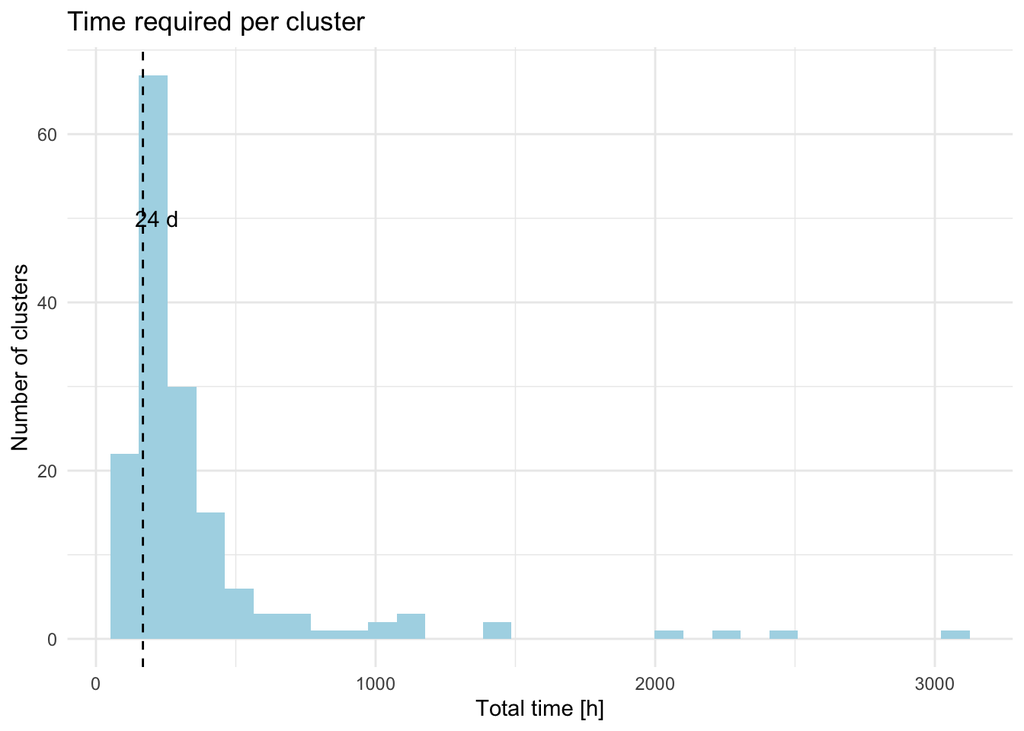

```r
field_worker_capacity <- (8-1)*24

df.workload %<>%
  mutate( total_time = cluster_visit_time + cluster_travel_time )

ggplot( df.workload, aes(total_time)) +
  geom_histogram(fill="lightblue") +
  geom_vline( xintercept = field_worker_capacity, linetype="dashed") +
  annotate( "text", x=50+field_worker_capacity, y=50, label="24 d") +
  labs( title = "Time required per cluster",
        x = "Total time [h]",
        y = "Number of clusters") +
  theme_minimal()
```

## Total estimates

Total workload for site in [h]

```r
site_work_load <- sum(df.workload$total_time)
site_work_load
```

```
## [1] 58299.45
```

Given field worker capacity, calculate number of field workers required.

- personal preference (familiarity with terrain)
- environmental factors like rainfall requiring re-routing

```r
site_work_load / field_worker_capacity
```

```
## [1] 347.0205
```

## Visualization

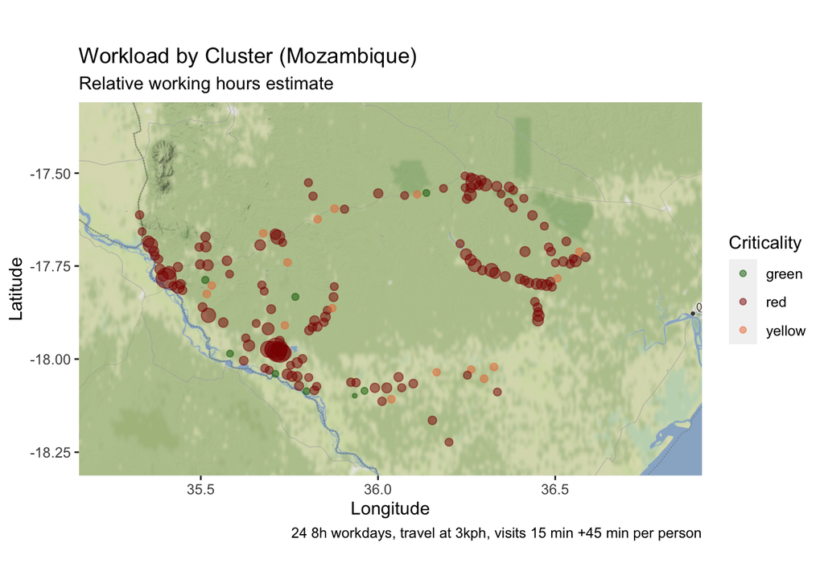

```r
max_time <- max(df.workload$total_time)
df.workload %<>%
  mutate( node_weight = total_time / max_time,
          criticality = case_when(
            total_time > field_worker_capacity*.95 ~ "red",
            total_time < field_worker_capacity*.8 ~ "green",
            TRUE ~ "yellow"
          ))

ggmap( map.moz ) +
  geom_point( data=df.workload, aes(lng, lat, size=node_weight, color=criticality), alpha=0.5 ) +
  scale_color_manual(values=c("red" = "darkred", "yellow"="sienna2", "green" = "darkgreen")) +
  labs( title="Workload by Cluster (Mozambique)",
        subtitle="Relative working hours estimate",
        caption="24 8h workdays, travel at 3kph, visits 15 min +45 min per person",
        x="Longitude",
        y="Latitude",
        color="Criticality") +
  guides(size=F)
```

## Interactive table

```r
datatable(df.workload %>% select(-lng, -lat, -node_weight))
```

|  | cluster | cluster_visit_time | n | tour | cluster_travel_time | total_time | criticality |
| --- | --- | --- | --- | --- | --- | --- | --- |
| 1 | 1 | 213 | 48 | 6344.05835767747 | 26.1146861192258 | 239.114686119226 | red |
| 2 | 2 | 171 | 48 | 10082.3384577967 | 27.3607794859322 | 198.360779485932 | red |
| 3 | 3 | 178.75 | 43 | 5937.5662836916 | 23.4791887612305 | 202.229188761231 | red |
| 4 | 4 | 219.25 | 52 | 9127.2236007497 | 29.0424078669166 | 248.292407866917 | red |
| 5 | 5 | 248.25 | 63 | 4014.15950547917 | 32.8380531684931 | 281.088053168493 | red |
| 6 | 6 | 395.75 | 104 | 4101.31563287842 | 53.3671052109595 | 449.117105210959 | red |
| 7 | 7 | 381.75 | 84 | 4722.27597021058 | 43.5740919900702 | 425.32409199007 | red |
| 8 | 8 | 186.5 | 50 | 5084.28636226717 | 26.6947621207557 | 213.194762120756 | red |
| 9 | 9 | 189.25 | 49 | 5200.48201671723 | 26.2334940055724 | 215.483494005572 | red |
| 10 | 10 | 322.75 | 79 | 6987.09901211429 | 41.8290330040381 | 364.579033004038 | red |

[output cut: 149 more lines]